# Purchasing power parities (PPPs)

H. Suzuki

2023-12-13

#### Fact Sheet: An Adjustment to Global Poverty Lines [[Link](https://www.worldbank.org/en/news/factsheet/2022/05/02/fact-sheet-an-adjustment-to-global-poverty-lines)]

The World Bank updated the global poverty lines in September 2022. The decision, announced in May, follows the release in 2020 of new purchasing power parities (PPPs)—the main data used to convert different currencies into a common, comparable unit and account for price differences across countries. The new extreme poverty line of $2.15 per person per day, which replaces the $1.90 poverty line, is based on 2017 PPPs. Here you find more information about this change and what it means for measuring global poverty.

- GDP per capita, PPP (constant 2017 international $): NY.GDP.PCAP.PP.KD

Step 1. If not installed, run only once.

```r
install.packages("tidyverse")
install.packages("WDI")
```

Step 2. Load the packages.

```r
library(tidyverse)
library(WDI)
```

Step 3. Change the system language if your system language is not English.

```r
Sys.setenv(LANG = "en")
```

Step 4. Indicators and descriptions of three types of GDP.

- GDP (current US$): NY.GDP.MKTP.CD
- GDP (constant 2015 US$): NY.GDP.MKTP.KD
- GDP, PPP (constant 2017 international $): NY.GDP.MKTP.PP.KD

```r
rbind(WDIsearch(string = "NY.GDP.MKTP.CD", field = "indicator", short = FALSE),
      WDIsearch(string = "NY.GDP.MKTP.KD", field = "indicator", short = FALSE),
      WDIsearch(string = "NY.GDP.MKTP.PP.KD", field = "indicator", short = FALSE)) |>
  filter(name %in% c("GDP (current US$)", "GDP (constant 2015 US$)", "GDP, PPP (constant 2017 international $)"))
```

| indicator | name | description | sourceDatabase | sourceOrganization |
| --- | --- | --- | --- | --- |
| NY.GDP.MKTP.CD | GDP (current US$) | GDP at purchaser's prices is the sum of gross value added by all resident producers in the economy plus any product taxes and minus any subsidies not included in the value of the products. It is calcu… | World Development Indicators | World Bank national accounts data, and OECD National Accounts data files. |
| NY.GDP.MKTP.KD | GDP (constant 2015 US$) | GDP at purchaser's prices is the sum of gross value added by all resident producers in the economy plus any product taxes and minus any subsidies not included in the value of the products. It is calcu… | World Development Indicators | World Bank national accounts data, and OECD National Accounts data files. |
| NY.GDP.MKTP.PP.KD | GDP, PPP (constant 2017 international $) | PPP GDP is gross domestic product converted to international dollars using purchasing power parity rates. An international dollar has the same purchasing power over GDP as the U.S. dollar has in the U… | World Development Indicators | International Comparison Program, World Bank \| World Development Indicators database, World Bank \| Eurostat-OECD PPP Programme. |

Step 4. Download data.

```r
df_3gdp <- WDI(indicator = c(gdp_nominal = "NY.GDP.MKTP.CD", gdp_real = "NY.GDP.MKTP.KD", gdp_ppp = "NY.GDP.MKTP.PP.KD"), extra = TRUE)
```

Step 5. Head, showing the first 6 rows.

```r
head(df_3gdp)
```

|  | country | iso2c | iso3c | year | status | lastupdated | gdp_nominal | gdp_real | gdp_ppp | region | capital | longitude | latitude | income | lending |
| --- | --- | --- | --- | --- | --- | --- | --- | --- | --- | --- | --- | --- | --- | --- | --- |
| 1 | Afghanistan | AF | AFG | 2014 |  | 2023-10-26 | 20550582747 | 19712059625 | 70158264545 | South Asia | Kabul | 69.1761 | 34.5228 | Low income | IDA |
| 2 | Afghanistan | AF | AFG | 1971 |  | 2023-10-26 | 1831108971 | NA | NA | South Asia | Kabul | 69.1761 | 34.5228 | Low income | IDA |
| 3 | Afghanistan | AF | AFG | 2006 |  | 2023-10-26 | 6971383339 | 9772076665 | 34780330056 | South Asia | Kabul | 69.1761 | 34.5228 | Low income | IDA |
| 4 | Afghanistan | AF | AFG | 2013 |  | 2023-10-26 | 20564485419 | 19189240448 | 68297470349 | South Asia | Kabul | 69.1761 | 34.5228 | Low income | IDA |
| 5 | Afghanistan | AF | AFG | 1995 |  | 2023-10-26 | NA | NA | NA | South Asia | Kabul | 69.1761 | 34.5228 | Low income | IDA |
| 6 | Afghanistan | AF | AFG | 2005 |  | 2023-10-26 | 6226198935 | 9275168487 | 33011757108 | South Asia | Kabul | 69.1761 | 34.5228 | Low income | IDA |

Step 6. Structure, showing all the columns, i.e., variables.

```r
str(df_3gdp)
```

```
'data.frame':   16758 obs. of  15 variables:
 $ country    : chr  "Afghanistan" "Afghanistan" "Afghanistan" "Afghanistan" ...
 $ iso2c      : chr  "AF" "AF" "AF" "AF" ...
 $ iso3c      : chr  "AFG" "AFG" "AFG" "AFG" ...
 $ year       : int  2014 1971 2006 2013 1995 2005 1997 1998 1999 1996 ...
 $ status     : chr  "" "" "" "" ...
 $ lastupdated: chr  "2023-10-26" "2023-10-26" "2023-10-26" "2023-10-26" ...
 $ gdp_nominal: num  2.06e+10 1.83e+09 6.97e+09 2.06e+10 NA ...
  ..- attr(*, "label")= chr "GDP (current US$)"
 $ gdp_real   : num  1.97e+10 NA 9.77e+09 1.92e+10 NA ...
  ..- attr(*, "label")= chr "GDP (constant 2015 US$)"
 $ gdp_ppp    : num  7.02e+10 NA 3.48e+10 6.83e+10 NA ...
  ..- attr(*, "label")= chr "GDP, PPP (constant 2017 international $)"
 $ region     : chr  "South Asia" "South Asia" "South Asia" "South Asia" ...
 $ capital    : chr  "Kabul" "Kabul" "Kabul" "Kabul" ...
 $ longitude  : chr  "69.1761" "69.1761" "69.1761" "69.1761" ...
 $ latitude   : chr  "34.5228" "34.5228" "34.5228" "34.5228" ...
 $ income     : chr  "Low income" "Low income" "Low income" "Low income" ...
 $ lending    : chr  "IDA" "IDA" "IDA" "IDA" ...
```

Step 7. Select columns.

```r
df_gdps <- df_3gdp |> select(c("country", "iso2c", "year", "gdp_nominal", "gdp_real", "gdp_ppp", "region", "income"))
head(df_gdps)
```

|  | country | iso2c | year | gdp_nominal | gdp_real | gdp_ppp | region | income |
| --- | --- | --- | --- | --- | --- | --- | --- | --- |
| 1 | Afghanistan | AF | 2014 | 20550582747 | 19712059625 | 70158264545 | South Asia | Low income |
| 2 | Afghanistan | AF | 1971 | 1831108971 | NA | NA | South Asia | Low income |
| 3 | Afghanistan | AF | 2006 | 6971383339 | 9772076665 | 34780330056 | South Asia | Low income |
| 4 | Afghanistan | AF | 2013 | 20564485419 | 19189240448 | 68297470349 | South Asia | Low income |
| 5 | Afghanistan | AF | 1995 | NA | NA | NA | South Asia | Low income |
| 6 | Afghanistan | AF | 2005 | 6226198935 | 9275168487 | 33011757108 | South Asia | Low income |

Step 8. List regions and income levels.

```r
df_gdps |> select(region, income) |> lapply(unique)
```

```
$region
[1] "South Asia"                 "Aggregates"
[3] "Europe & Central Asia"      "Middle East & North Africa"
[5] "East Asia & Pacific"        "Sub-Saharan Africa"
[7] "Latin America & Caribbean"  "North America"
[9] NA

$income
[1] "Low income"          "Aggregates"          "Upper middle income"
[4] "Lower middle income" "High income"         NA
[7] "Not classified"
```

Step 9. Make a long table using `pivot_longer` .

```r
df_gdps_long <- df_gdps |>
  pivot_longer(cols = c("gdp_nominal", "gdp_real", "gdp_ppp"),
               names_to = "gdp", values_to = "value")
```

Step 10. Set groups.

```r
INCOME <- c("Low income", "Low & middle income", "Lower middle income", "Middle income", "Upper middle income", "High income")
REGION <- c("South Asia", "Europe & Central Asia", "Middle East & North Africa", "East Asia & Pacific", "Sub-Saharan Africa", "Latin America & Caribbean",  "North America")
```

Step 11. Find an appropriate list of countries.

```r
df_gdps_long |>
  filter(!(region %in% c("Aggregates"))) |>
  filter(!(country %in% c(INCOME, REGION, "Not classified"))) |>
  distinct(country, iso2c, region)
```

| country | iso2c | region |
| --- | --- | --- |
| Afghanistan | AF | South Asia |
| Albania | AL | Europe & Central Asia |
| Algeria | DZ | Middle East & North Africa |
| American Samoa | AS | East Asia & Pacific |
| Andorra | AD | Europe & Central Asia |
| Angola | AO | Sub-Saharan Africa |
| Antigua and Barbuda | AG | Latin America & Caribbean |
| Argentina | AR | Latin America & Caribbean |
| Armenia | AM | Europe & Central Asia |
| Aruba | AW | Latin America & Caribbean |

[output cut: 207 more lines]

Step 12. Create new tables, `df_gdps_countries` and `df_gdps_long_countries`with countries only.

```r
df_gdps_countries <- df_gdps |>
  filter(!(region %in% c("Aggregates"))) |>
  filter(!(country %in% c(INCOME, REGION, "Not classified")))
df_gdps_long_countries <- df_gdps_long |>
  filter(!(region %in% c("Aggregates"))) |>
  filter(!(country %in% c(INCOME, REGION, "Not classified")))
```

### Visualization

Chart 1. GDPs of the World.

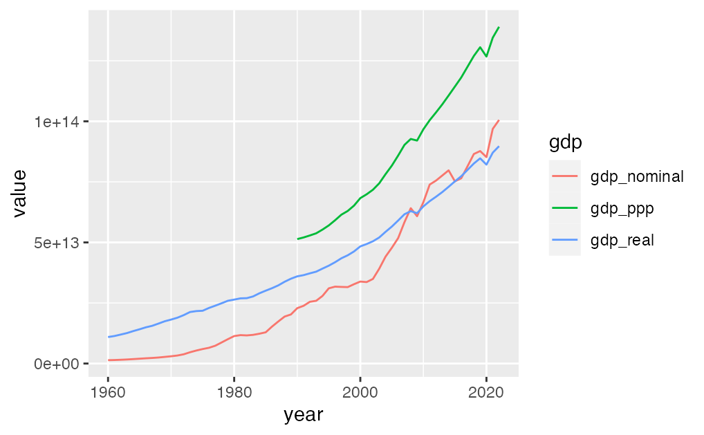

```r
df_gdps_long |> filter(country == "World") |>
  ggplot(aes(year, value, col = gdp)) + geom_line()
```

Chart 2. GDPs of the World after 1990.

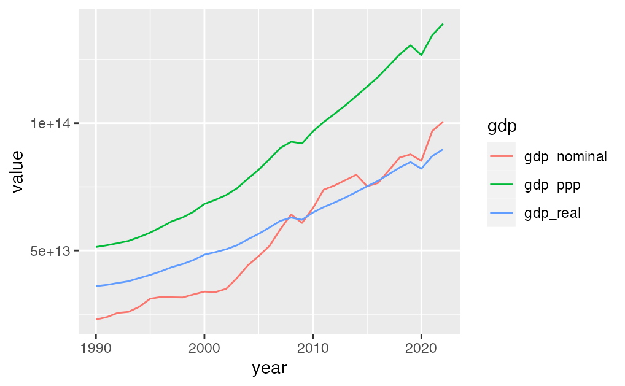

```r
df_gdps_long |> filter(country == "World") |>
  filter(year >= 1990) |>
  ggplot(aes(year, value, col = gdp)) + geom_line()
```

Chart 3. Ranks of countries in each GDP.

```r
df_gdps_countries |> filter(year == 2022) |> drop_na(gdp_nominal, gdp_real, gdp_ppp) |>
  arrange(desc(gdp_nominal)) |> select(country, iso2c, gdp_nominal)
```

| country | iso2c | gdp_nominal |
| --- | --- | --- |
| United States | US | 2.546270e+13 |
| China | CN | 1.796317e+13 |
| Japan | JP | 4.231141e+12 |
| Germany | DE | 4.072192e+12 |
| India | IN | 3.385090e+12 |
| United Kingdom | GB | 3.070668e+12 |
| France | FR | 2.782905e+12 |
| Russian Federation | RU | 2.240422e+12 |
| Canada | CA | 2.139840e+12 |
| Italy | IT | 2.010432e+12 |

[output cut: 174 more lines]

```r
df_gdps_countries |> filter(year == 2022) |> drop_na(gdp_nominal, gdp_real, gdp_ppp) |>
  arrange(desc(gdp_real)) |> select(country, iso2c, gdp_real)
```

| country | iso2c | gdp_real |
| --- | --- | --- |
| United States | US | 2.095269e+13 |
| China | CN | 1.632521e+13 |
| Japan | JP | 4.508553e+12 |
| Germany | DE | 3.618134e+12 |
| United Kingdom | GB | 3.163212e+12 |
| India | IN | 2.954978e+12 |
| France | FR | 2.643644e+12 |
| Italy | IT | 1.936547e+12 |
| Brazil | BR | 1.901461e+12 |
| Canada | CA | 1.748359e+12 |

[output cut: 174 more lines]

```r
df_gdps_countries |> filter(year == 2022) |> drop_na(gdp_nominal, gdp_real, gdp_ppp) |>
  arrange(desc(gdp_ppp)) |> select(country, iso2c, gdp_ppp)
```

| country | iso2c | gdp_ppp |
| --- | --- | --- |
| China | CN | 2.568461e+13 |
| United States | US | 2.156470e+13 |
| India | IN | 1.005674e+13 |
| Japan | JP | 5.210350e+12 |
| Germany | DE | 4.503322e+12 |
| Russian Federation | RU | 4.027358e+12 |
| Indonesia | ID | 3.418905e+12 |
| Brazil | BR | 3.249827e+12 |
| United Kingdom | GB | 3.136344e+12 |
| France | FR | 3.126376e+12 |

[output cut: 174 more lines]

Chart 4. Line graphs of top 10 countries in each GDP.

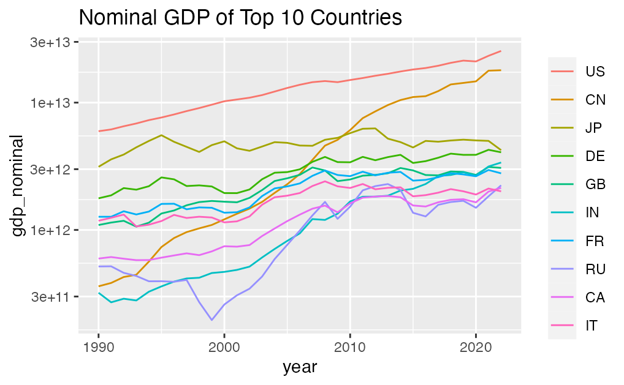

```r
ISO2CN10 <- c("US", "CN", "JP", "DE", "GB", "IN", "FR", "RU", "CA","IT")
df_gdps_countries |> filter(year >=1990) |>
  filter(iso2c %in% ISO2CN10) |>
  ggplot(aes(year, gdp_nominal, col = factor(iso2c, levels = ISO2CN10))) + geom_line() + scale_y_log10() +labs(title = "Nominal GDP of Top 10 Countries", col = "")
```

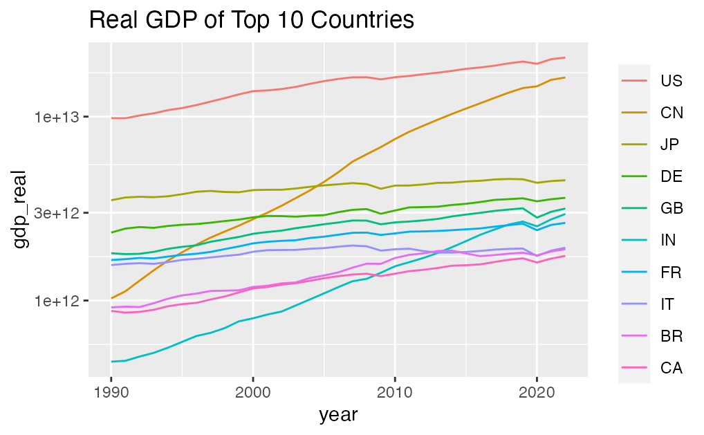

```r
ISO2CR10 <- c("US", "CN", "JP", "DE", "GB", "IN", "FR", "IT", "BR","CA")
df_gdps_countries |> filter(year >=1990) |>
  filter(iso2c %in% ISO2CR10) |>
  ggplot(aes(year, gdp_real, col = factor(iso2c, levels = ISO2CR10))) + geom_line() + scale_y_log10() +labs(title = "Real GDP of Top 10 Countries", col = "")
```

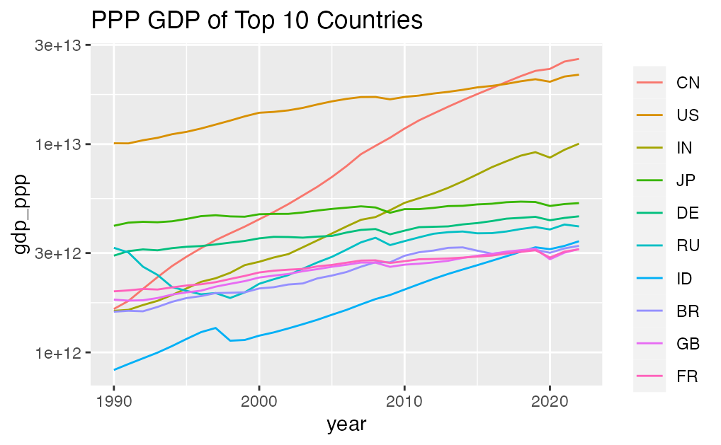

```r
ISO2CP10 <- c("CN", "US", "IN", "JP", "DE", "RU", "ID", "BR", "GB","FR")
df_gdps_countries |> filter(year >=1990) |>
  filter(iso2c %in% ISO2CP10) |>
  ggplot(aes(year, gdp_ppp, col = factor(iso2c, levels = ISO2CP10))) + geom_line() + scale_y_log10() +labs(title = "PPP GDP of Top 10 Countries", col = "")
```

Chart 5. Line graph of chosen countries.

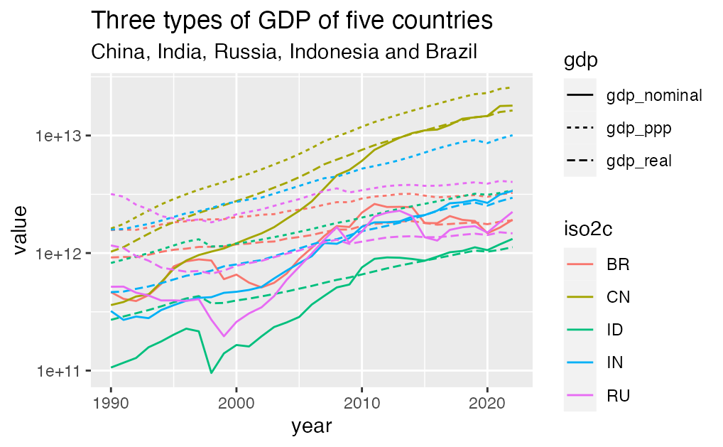

```r
ISO2C_selected <- c("CN", "IN", "RU", "ID", "BR")
df_gdps_long |> filter(iso2c %in% ISO2C_selected) |>
  filter(year >= 1990) |>
  ggplot(aes(year, value, col = iso2c, linetype = gdp)) +
  geom_line() + scale_y_log10() +
  labs(title = "Three types of GDP of five countries",
       subtitle = "China, India, Russia, Indonesia and Brazil")
```

### Notes

- There are many world development indicators related to gdp.

```r
WDIsearch(string = "gdp", field = "name", short = TRUE, cache = NULL)
```

|  | indicator | name |
| --- | --- | --- |
| 712 | 5.51.01.10.gdp | Per capita GDP growth |
| 714 | 6.0.GDP_current | GDP (current $) |
| 715 | 6.0.GDP_growth | GDP growth (annual %) |
| 716 | 6.0.GDP_usd | GDP (constant 2005 $) |
| 717 | 6.0.GDPpc_constant | GDP per capita, PPP (constant 2011 international $) |
| 1557 | BG.GSR.NFSV.GD.ZS | Trade in services (% of GDP) |
| 1558 | BG.KAC.FNEI.GD.PP.ZS | Gross private capital flows (% of GDP, PPP) |
| 1559 | BG.KAC.FNEI.GD.ZS | Gross private capital flows (% of GDP) |
| 1560 | BG.KLT.DINV.GD.PP.ZS | Gross foreign direct investment (% of GDP, PPP) |
| 1561 | BG.KLT.DINV.GD.ZS | Gross foreign direct investment (% of GDP) |

[output cut: 530 more lines]

- Regions are not available in some countries. Be careful when you select a list of countries.
- Write your observations and questions.